hReproducible Research: Peer Assessment 1

T. van Dam

Load the libraries

```r
library(data.table)
library(ggplot2)
```

```r
knitr::opts_chunk$set(
  fig.path = "images/")
```

Load the data ‘activity.csv’ previously downloaded from Coursera (https://www.coursera.org/learn/reproducible-research/peer/gYyPt/course-project-1)

```r
aData <- read.csv('activity.csv')
summary(aData)
```

```
##      steps                date          interval
##  Min.   :  0.00   2012-10-01:  288   Min.   :   0.0
##  1st Qu.:  0.00   2012-10-02:  288   1st Qu.: 588.8
##  Median :  0.00   2012-10-03:  288   Median :1177.5
##  Mean   : 37.38   2012-10-04:  288   Mean   :1177.5
##  3rd Qu.: 12.00   2012-10-05:  288   3rd Qu.:1766.2
##  Max.   :806.00   2012-10-06:  288   Max.   :2355.0
##  NA's   :2304     (Other)   :15840
```

What is the mean total number of steps taken per day?

Assign the Date class to date and Factor class to interval

```r
aData$date <- as.Date(aData$date, format = "%Y-%m-%d")
aData$interval <- as.factor(aData$interval)
```

Calculate the total steps per day ignoring NA

```r
day_steps <- aggregate(steps ~ date, aData, sum)
colnames(day_steps) <- c("date","steps")
head(day_steps)
```

```
##         date steps
## 1 2012-10-02   126
## 2 2012-10-03 11352
## 3 2012-10-04 12116
## 4 2012-10-05 13294
## 5 2012-10-06 15420
## 6 2012-10-07 11015
```

Create a histogram of the steps per day

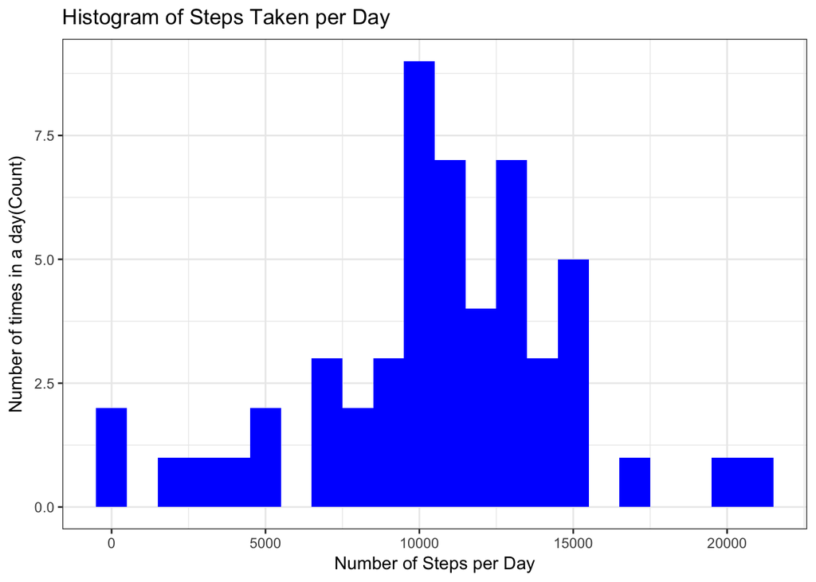

```r
knitr::opts_chunk$set(
  fig.path = "images/")
ggplot(day_steps, aes(x = steps)) +
        geom_histogram(fill = "blue", binwidth = 1000) +
         labs(title="Histogram of Steps Taken per Day",
         x = "Number of Steps per Day", y = "Number of times in a day(Count)") + theme_bw()
```

Calculate the mean and the median number of steps per day

```r
steps_mean   <- mean(day_steps$steps, na.rm=TRUE)
steps_median <- median(day_steps$steps, na.rm=TRUE)
steps_mean
```

```
## [1] 10766.19
```

```r
steps_median
```

```
## [1] 10765
```

The mean is 10766.189 and median is 10765.

What is the average daily activity pattern?

Calculate the aggregation of steps by intervals of 5-minutes and convert the intervals as integers and save them in a data frame called steps_per_interval.

```r
steps_per_interval <- aggregate(aData$steps,
                                by = list(interval = aData$interval),
                                FUN=mean, na.rm=TRUE)
#convert to integers
##this helps in plotting
steps_per_interval$interval <-
        as.integer(levels(steps_per_interval$interval)[steps_per_interval$interval])
colnames(steps_per_interval) <- c("interval", "steps")
str(steps_per_interval)
```

```
## 'data.frame':    288 obs. of  2 variables:
##  $ interval: int  0 5 10 15 20 25 30 35 40 45 ...
##  $ steps   : num  1.717 0.3396 0.1321 0.1509 0.0755 ...
```

Plot the time series of the average number of steps taken.

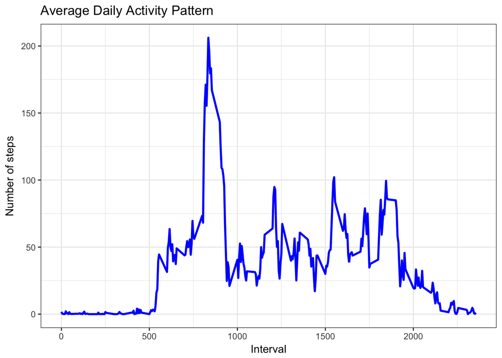

```r
ggplot(steps_per_interval, aes(x=interval, y=steps)) +
        geom_line(color="blue", size=1) +
        labs(title="Average Daily Activity Pattern", x="Interval",y="Number of steps") +
        theme_bw()
```

Find the 5-minute interval containing the maximum number of steps.

```r
max_interval <- steps_per_interval[which.max(
        steps_per_interval$steps),]
max_interval
```

```
##     interval    steps
## 104      835 206.1698
```

Interval 835 has the most steps; it has 206 steps.

Imputing the missing values: Calculate the total number of missing values in steps

```r
missing_vals <- sum(is.na(aData$steps))
missing_vals
```

```
## [1] 2304
```

There are a total of 2304 missing values.

```r
aData_new <- merge(aData, day_steps, by="date", suffixes=c("", ".mean"))
nas <- is.na(aData_new$steps)
aData_new$steps[nas] <- aData_new$steps.mean[nas]
aData_new <- aData_new[, c(1:3)]
head(aData_new)
```

```
##         date steps interval
## 1 2012-10-02     0     1740
## 2 2012-10-02     0     1715
## 3 2012-10-02     0     1725
## 4 2012-10-02     0     1710
## 5 2012-10-02     0     1735
## 6 2012-10-02     0     1855
```

Make a histogram of the total number of steps taken each day

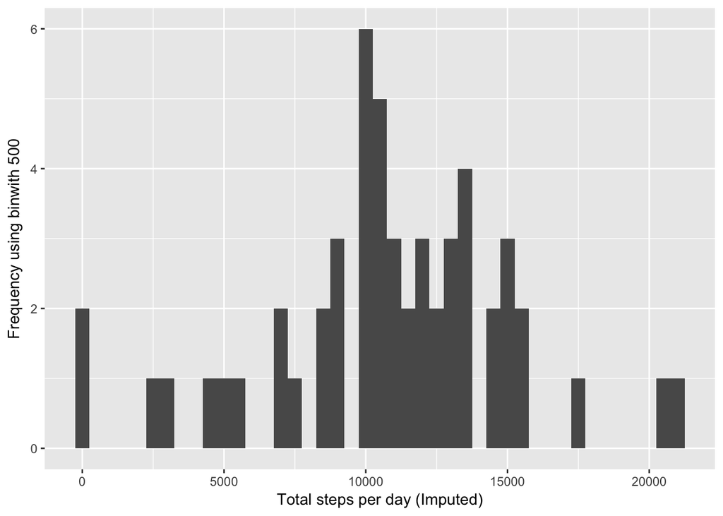

```r
day_steps_new <- tapply(aData_new$steps, aData_new$date, sum)
qplot(day_steps_new, xlab='Total steps per day (Imputed)', ylab='Frequency using binwith 500', binwidth=500)
```

Calculate the total number of steps taken per day

```r
steps_mean_new   <- mean(day_steps_new)
steps_median_new <- median(day_steps_new)
steps_mean_new
```

```
## [1] 10766.19
```

```r
steps_median_new
```

```
## [1] 10765
```

The mean of the total number of steps taken per day = 10766 The median of the total number of steps taken per day = 10765

Are there differences in activity patterns patterns between weekdays and weekends?

Add new factor variable dayType with 2 levels – “weekday” and “weekend”

```r
dayType <- function(dates) {
  f <- function(date) {
    if (weekdays(date) %in% c("Saturday", "Sunday")) {
      "weekend"
    }
    else {
      "weekday"
    }
  }
  sapply(dates, f)
}
aData$wday <- as.factor(dayType(aData$date))
head(aData)
```

```
##   steps       date interval    wday
## 1    NA 2012-10-01        0 weekday
## 2    NA 2012-10-01        5 weekday
## 3    NA 2012-10-01       10 weekday
## 4    NA 2012-10-01       15 weekday
## 5    NA 2012-10-01       20 weekday
## 6    NA 2012-10-01       25 weekday
```

```r
str(aData)
```

```
## 'data.frame':    17568 obs. of  4 variables:
##  $ steps   : int  NA NA NA NA NA NA NA NA NA NA ...
##  $ date    : Date, format: "2012-10-01" "2012-10-01" ...
##  $ interval: Factor w/ 288 levels "0","5","10","15",..: 1 2 3 4 5 6 7 8 9 10 ...
##  $ wday    : Factor w/ 2 levels "weekday","weekend": 1 1 1 1 1 1 1 1 1 1 ...
```

Create a plot containing a time series plot of the 5-minute interval (x-axis) and the average number of steps taken, averaged across all weekdays and weekends

```r
steps_per_interval<-aggregate(steps ~ interval + wday, aData, mean)
head(steps_per_interval)
```

```
##   interval    wday     steps
## 1        0 weekday 2.3333333
## 2        5 weekday 0.4615385
## 3       10 weekday 0.1794872
## 4       15 weekday 0.2051282
## 5       20 weekday 0.1025641
## 6       25 weekday 1.5128205
```

```r
str(steps_per_interval)
```

```
## 'data.frame':    576 obs. of  3 variables:
##  $ interval: Factor w/ 288 levels "0","5","10","15",..: 1 2 3 4 5 6 7 8 9 10 ...
##  $ wday    : Factor w/ 2 levels "weekday","weekend": 1 1 1 1 1 1 1 1 1 1 ...
##  $ steps   : num  2.333 0.462 0.179 0.205 0.103 ...
```

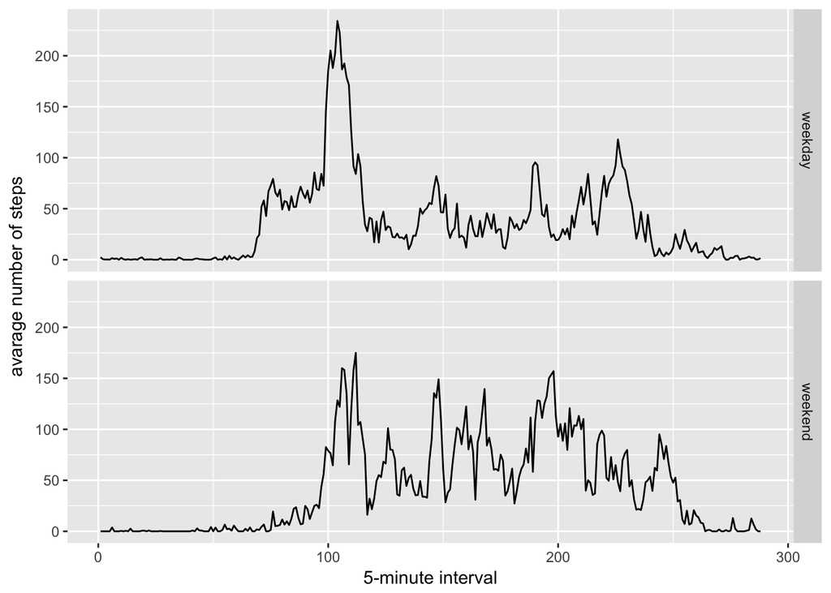

```r
ggplot(steps_per_interval, aes(as.numeric(interval), steps)) +
    geom_line() +
    facet_grid(wday ~ .) +
    xlab("5-minute interval") +
    ylab("avarage number of steps")
```